# Pre-Seminar-Task

2026-01-28

# Change the Serial Interval Mean and STD and compare

```
## # A tibble: 61 × 6
##    areaType areaName areaCode  date       newCasesBySpecimenDate
##    <chr>    <chr>    <chr>     <date>                      <dbl>
##  1 region   London   E12000007 2020-04-03                    985
##  2 region   London   E12000007 2020-04-02                   1063
##  3 region   London   E12000007 2020-04-01                    977
##  4 region   London   E12000007 2020-03-31                    935
##  5 region   London   E12000007 2020-03-30                    848
##  6 region   London   E12000007 2020-03-29                    596
##  7 region   London   E12000007 2020-03-28                    577
##  8 region   London   E12000007 2020-03-27                    818
##  9 region   London   E12000007 2020-03-26                    740
## 10 region   London   E12000007 2020-03-25                    752
## # ℹ 51 more rows
## # ℹ 1 more variable: cumCasesBySpecimenDate <dbl>
```

```
## # A tibble: 61 × 6
##    areaType areaName areaCode  date       newCasesBySpecimenDate
##    <chr>    <chr>    <chr>     <date>                      <dbl>
##  1 region   London   E12000007 2020-02-03                      1
##  2 region   London   E12000007 2020-02-04                      0
##  3 region   London   E12000007 2020-02-05                      0
##  4 region   London   E12000007 2020-02-06                      0
##  5 region   London   E12000007 2020-02-07                      0
##  6 region   London   E12000007 2020-02-08                      0
##  7 region   London   E12000007 2020-02-09                      0
##  8 region   London   E12000007 2020-02-10                      1
##  9 region   London   E12000007 2020-02-11                      4
## 10 region   London   E12000007 2020-02-12                      0
## # ℹ 51 more rows
## # ℹ 1 more variable: cumCasesBySpecimenDate <dbl>
```

```
## <incidence object>
## [61 cases from days 2020-02-03 to 2020-04-03]
##
## $counts: matrix with 61 rows and 1 columns
## $n: 61 cases in total
## $dates: 61 dates marking the left-side of bins
## $interval: 1 day
## $timespan: 61 days
## $cumulative: FALSE
```

## Before

```r
s_interval <- make_config(
  mean_si = 12.0,
  std_si = 5.2
)
```

```r
my_R <- estimate_R(i, method= "parametric_si", config = s_interval)
```

```
## Default config will estimate R on weekly sliding windows.
##     To change this change the t_start and t_end arguments.
```

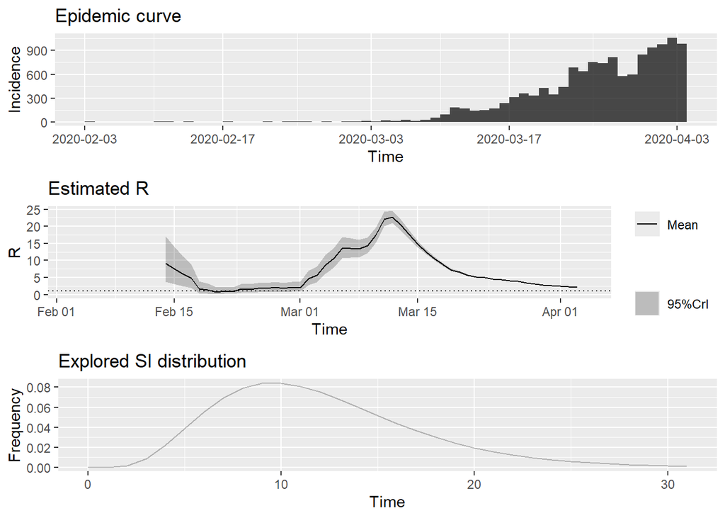

```r
plot(my_R)
```

```r
my_R$R
```

```
##    t_start t_end    Mean(R)     Std(R) Quantile.0.025(R) Quantile.0.05(R)
## 1        2     8         NA         NA                NA               NA
## 2        3     9         NA         NA                NA               NA
## 3        4    10         NA         NA                NA               NA
## 4        5    11         NA         NA                NA               NA
## 5        6    12  9.1581735 3.46146423        3.68206074        4.2982130
## 6        7    13  7.5450388 2.85175663        3.03349694        3.5411192
## 7        8    14  6.0426074 2.28389093        2.42944158        2.8359819
## 8        9    15  4.7875870 1.80953780        1.92485828        2.2469621
## 9       10    16  1.6385952 0.94604338        0.33791772        0.4466218
## 10      11    17  1.3351883 0.77087130        0.27534792        0.3639240
## 11      12    18  0.7455391 0.52717577        0.09028825        0.1324680
## 12      13    19  0.9692400 0.55959096        0.19988059        0.2641797
## 13      14    20  0.8722675 0.50360387        0.17988253        0.2377486
## 14      15    21  1.6293427 0.66517636        0.59794004        0.7095827
```

[output cut: 150 more lines]

## Updating Mean and STD

```r
new_s_interval <- make_config(
  mean_si = 6.0,
  std_si = 3.5
)
```

```r
new_my_R <- estimate_R(i, method= "parametric_si", config = new_s_interval)
```

```
## Default config will estimate R on weekly sliding windows.
##     To change this change the t_start and t_end arguments.
```

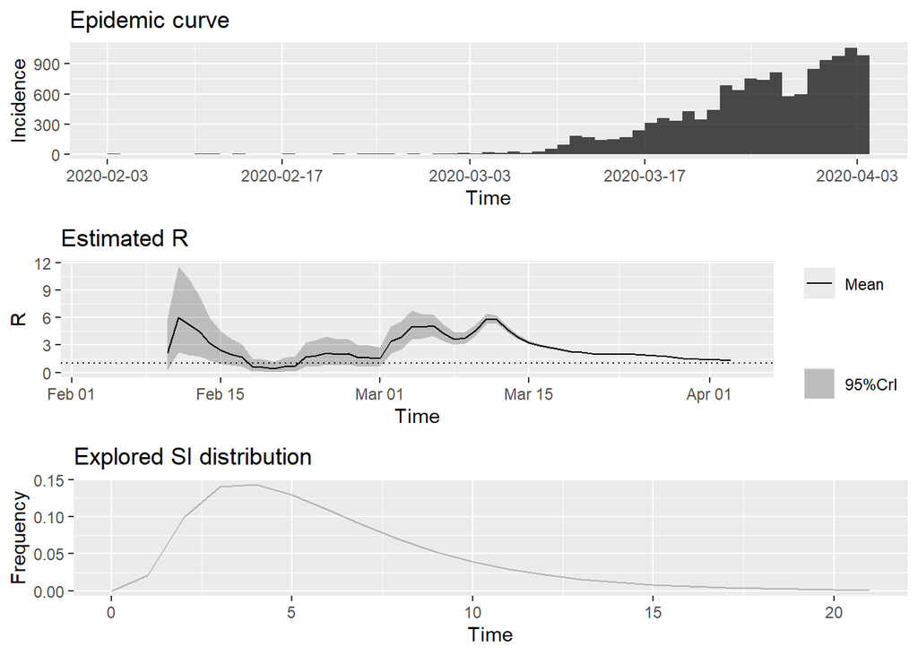

```r
plot(new_my_R)
```

```r
new_my_R$R
```

```
##    t_start t_end   Mean(R)     Std(R) Quantile.0.025(R) Quantile.0.05(R)
## 1        2     8 2.1451765 1.51686885        0.25979083        0.3811566
## 2        3     9 5.9924361 2.44640178        2.19911842        2.6097206
## 3        4    10 5.2766023 2.15416386        1.93642004        2.2979733
## 4        5    11 4.4473601 1.68094410        1.78806940        2.0872831
## 5        6    12 3.2018891 1.21020031        1.28732546        1.5027452
## 6        7    13 2.4274951 0.91750690        0.97597892        1.1392982
## 7        8    14 1.9662947 0.74318956        0.79055247        0.9228427
## 8        9    15 1.6854293 0.63703239        0.67762999        0.7910239
## 9       10    16 0.6459763 0.37295462        0.13321585        0.1760698
## 10      11    17 0.6058071 0.34976292        0.12493200        0.1651211
## 11      12    18 0.4116799 0.29110166        0.04985635        0.0731476
## 12      13    19 0.6657879 0.38439284        0.13730148        0.1814697
## 13      14    20 0.7456043 0.43047485        0.15376153        0.2032248
## 14      15    21 1.6713164 0.68231206        0.61334366        0.7278624
```

[output cut: 150 more lines]

By setting the mean to 6 and STD to 3.5, we can estimate the R number for the earlier date ranges as it now has enough data. Comparing the mean R value where the start date is 6 and end is 12, the new settings return a value which is around a third that of the original (9.2 vs 3.2). The same pattern applies to the STD and quantiles.

Changing the settings has no impact on the epidemic curve and the number of incidence.

When the mean and std is updated to 6 and 3.5, the SI distribution graph’s frequency peaks around day 4 which is significantly earlier than with the previous mean and std as it peaked around day 10.